# TRABAJO APRENDIZAJE AUTOMÁTICO

Guzmán Muñoz Revuelta

Fernando Caruana del Pino

En esta última parte del trabajo estudiaremos a fondo todos los modelos vistos en clase, y escogeremos el más óptimo en función de su exactitud, precisión, recall y f1-score de los 1 que se obtengan en la matriz de confusión. Los valores 1 eran los fraudes, objetivo buscado en este trabajo. Una vez trabajado con todos los modelos y escogido el mejor, le añadiremos hiperparámetros para intentar mejorar un poco los valores obtenidos. Los modelos realizados son:

- GLM
- Navies Gaussian Bayes
- Modelo de Árbol
- Support Vector Machine (SVM)
- RandomForest
- Perception Learning Rule
- XGBoost
- AdaBoost Classifier
- GradientBoost Classifier
- LightGBM

Además, una vez escogido el modelo óptimo, entraremos en el ámbito de la explicabilidad usando el SHAP. El SHAP (Shapley Additive exPlanations) es un conjunto de herramientas que crean una importancia a cada variable para la predicción de un modelo. De manera más práctica, el modelo se encarga de obtener unos valores SHAP, hace unos clústeres en función de esos valores y luego vuelve a la tabla raw para ver las características de los individuos que ha seleccionado en esos clústeres.

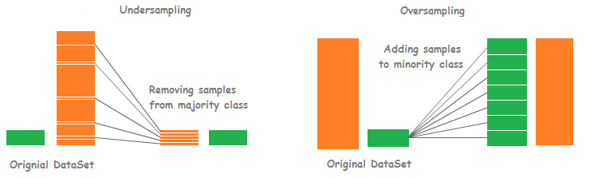

```python
import pandas as pd
import numpy as np
import sklearn
import warnings
warnings.filterwarnings("ignore")
from sklearn.pipeline import Pipeline
from sklearn import metrics
# conda install category_encoders
import category_encoders as ce
from sklearn.preprocessing import OneHotEncoder

import matplotlib.pyplot as plt
import seaborn as sns
from sklearn.ensemble import RandomForestClassifier, GradientBoostingClassifier
from sklearn import metrics

#from sklearn.metrics import plot_confusion_matrix, roc_curve, roc_auc_score
from sklearn.linear_model import Lasso, LogisticRegression
from sklearn.feature_selection import SelectFromModel, RFE
from sklearn.preprocessing import StandardScaler
from sklearn.tree import DecisionTreeClassifier
from sklearn.metrics import accuracy_score, classification_report, confusion_matrix
```

```python
X_train_scaled=pd.read_csv("../data/X_train_scaled.csv")
X_test_scaled=pd.read_csv("../data/X_test_scaled.csv")
y_train=pd.read_csv("../data/y_train.csv")
y_test=pd.read_csv("../data/y_test.csv")
```

```python
y_train=y_train.drop('Unnamed: 0', axis=1)
y_test=y_test.drop('Unnamed: 0', axis=1)
```

```python
from sklearn.model_selection import train_test_split

X_train_val, X_val = train_test_split(X_train_scaled, test_size=0.2, random_state=42)
```

```python
from sklearn.model_selection import train_test_split

y_train_val, y_val = train_test_split(y_train, test_size=0.2, random_state=42)
```

## UNDERSAMPLING

¿Qué es? El undersampling es una técnica utilizada para resolver el desbalance de clases en conjuntos de datos. Cuando se trabaja con problemas de clasificación, es común que algunas clases estén subrepresentadas en comparación con otras. Esto puede afectar el rendimiento del modelo, ya que puede volverse sesgado hacia la clase mayoritaria.

El undersampling consiste en reducir la cantidad de instancias de la clase mayoritaria para equilibrar las proporciones entre las clases. Esto se hace eliminando aleatoriamente instancias de la clase mayoritaria hasta que se alcance un equilibrio deseado. El objetivo del undersampling es mejorar la capacidad del modelo para generalizar y predecir con precisión las clases minoritarias, ya que al reducir la cantidad de instancias de la clase mayoritaria, el modelo se ve obligado a prestar más atención a las clases minoritarias durante el proceso de entrenamiento.

En esta parte del trabajo hemos decidido realizar finalmente un undersampling ya que comparándolo con un oversampling se han obtenido mejores resultados en los modelos (generalmente) y el tiempo de carga ha sido menor. Hay que mencionar que para cada modelo de undersampling hemos utilizado la librería 'time', para ver el tiempo de ejecución de los mismos.

Para obtener el undersampling final, hemos ido probando diferentes proporciones para la eliminación de 1 y 0, empezando por un 50% 50%, y tras muchos intentos donde salían los valores más óptimos ha sido eliminando el 85% de la clase 0 (No Fraude) y el 0% de la clase 1 (Fraude). Además, hemos creado las variables 'X_resampled, y_resampled', que son las que vamos a usar para realizar los modelos:

```python
from imblearn.under_sampling import RandomUnderSampler
count_class_0, count_class_1 = y_train_val.value_counts()

# Establecer la proporción deseada
undersampling_ratio_0 = 0.85  # Eliminar el 85% de la clase 0
undersampling_ratio_1 = 0 # Eliminar el 0% de la clase 1

# Calcular el nuevo número de instancias después del undersampling
target_count_class_0 = int(count_class_0 * (1 - undersampling_ratio_0))
target_count_class_1 = int(count_class_1 * (1 - undersampling_ratio_1))

# Configurar el RandomUnderSampler con las proporciones deseadas
rus = RandomUnderSampler(sampling_strategy={0: target_count_class_0, 1: target_count_class_1}, random_state=42)

# Aplicar el undersampling al conjunto de entrenamiento
X_resampled, y_resampled = rus.fit_resample(X_train_val, y_train_val)
```

Tras realizar el undersampling observamos que tenemos 94946 ceros (el 15% restante) y 7021 unos:

```python
rus
```

```
RandomUnderSampler(random_state=42, sampling_strategy={0: 94946, 1: 7021})
```

## ESTRATIFICADO

¿Qué es? El muestreo estratificado es otra técnica para resolver el problema del desbalance de clases de conjuntos de datos. A diferencia de las técnicas de oversampling y undersampling, que manipulan directamente la distribución de instancias de las clases, el muestreo estratificado se enfoca en dividir el conjunto de datos en estratos (o subconjuntos) y luego muestrear de manera proporcional desde cada estrato.

```python
import os
folder_path = os.path.join('..', 'models')
```

# Modelo Base

En esta parte se realizará un modelo como el visto en clase con el dataset Titanic, un modelo muy sencillo donde ninguno de los individuos realiza fraude (lo mismo que en el titanic cuando asumimos que todos morían) que se comparará más adelante con el modelo óptimo elegido.

```python
y_test2=y_test
```

```python
majority_class = y_test2['fraud_bool'].mode()[0]
y_test2['Predicted_fraud_bool'] = majority_class
```

```python
y_test= y_test.drop('Predicted_fraud_bool',axis=1)
```

```
Precisión del modelo base: 0.98897
```

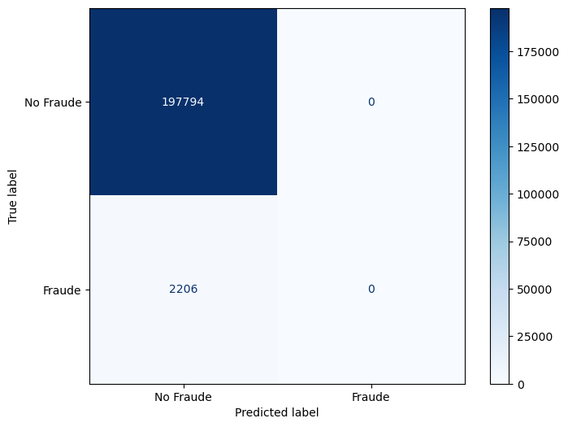

```
El script tardó 0.21337342262268066 segundos en ejecutarse.
```

```python
import seaborn as sns
from sklearn.metrics import confusion_matrix
import matplotlib.pyplot as plt
import time

start_time = time.time()

accuracy = accuracy_score(y_test,y_test2['Predicted_fraud_bool'])
print("Precisión del modelo base:", accuracy)
y_real = y_test
y_pred =y_test2['Predicted_fraud_bool']
display_labels = ['No Fraude', 'Fraude']
matriz_confusion = confusion_matrix(y_real, y_pred)

# Crea la visualización de la matriz de confusión
vis = sklearn.metrics.ConfusionMatrixDisplay(matriz_confusion, display_labels=display_labels)

# Muestra el gráfico
fig, ax = plt.subplots(figsize=(8, 6))
vis.plot(ax=ax, cmap='Blues', values_format='d', xticks_rotation='horizontal')
plt.show()
end_time = time.time()
elapsed_time = end_time - start_time
print(f"El script tardó {elapsed_time} segundos en ejecutarse.")
```

# GLM

El GLM (Modelo Linear Generalizado) es una generalización flexible de la regresión lineal ordinaria que permite variables de respuesta que tienen modelos de distribución de errores distintos de una distribución normal. El GLM generaliza la regresión lineal al permitir que el modelo lineal esté relacionado con la variable de respuesta a través de una función de enlace y al permitir que la magnitud de la varianza de cada medición sea una función de su valor predicho. Son una extensión de los modelos lineales tradicionales que permiten la especificación de distribuciones de probabilidad más generales y relaciones no lineales entre las variables dependientes e independientes. En este caso se trabaja con el train:

```
Accuracy of the logistic regression model: 0.98190625
Reporte de Clasificación:
              precision    recall  f1-score   support

           0       0.99      0.99      0.99    158198
           1       0.20      0.20      0.20      1802

    accuracy                           0.98    160000
   macro avg       0.60      0.60      0.60    160000
weighted avg       0.98      0.98      0.98    160000

Matriz de Confusión:
```

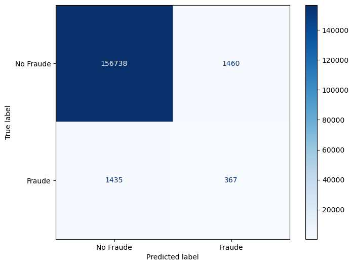

```
El script tardó 0 minutos y 1 segundos en ejecutarse.
```

```python
from sklearn.linear_model import LogisticRegression
import time

start_time = time.time()

# Create a logistic regression model
logreg = LogisticRegression()

# Fit the model on the undersampled data
logreg.fit(X_resampled, y_resampled)

# Predict on the test data
y_pred = logreg.predict(X_val)

# Evaluate the model
accuracy = accuracy_score(y_val, y_pred)
print("Accuracy of the logistic regression model:", accuracy)

print("Reporte de Clasificación:")
print(classification_report(y_val, y_pred))

print("Matriz de Confusión:")
matriz=confusion_matrix(y_val, y_pred)
display_labels = ['No Fraude', 'Fraude']

vis = sklearn.metrics.ConfusionMatrixDisplay(matriz, display_labels=display_labels)
fig, ax = plt.subplots(figsize=(8, 6))
vis.plot(ax=ax, cmap='Blues', values_format='d', xticks_rotation='horizontal')
plt.show()

model_name = 'modelo_GLM_rus.pkl'
pickle_file_path = os.path.join(folder_path, model_name)
with open(pickle_file_path, 'wb') as file:
    pickle.dump(logreg, file)


end_time = time.time()

elapsed_time_seconds = end_time - start_time

elapsed_minutes = int(elapsed_time_seconds // 60)
elapsed_seconds = int(elapsed_time_seconds % 60)

print(f"El script tardó {elapsed_minutes} minutos y {elapsed_seconds} segundos en ejecutarse.")
```

# BAYES

El modelo Naive Bayes hace la suposición de que las características son independientes dadas las clases, lo que simplifica la fórmula y los cálculos.El clasificador Naive Bayes se basa en el teorema de Bayes, que se utiliza para calcular las probabilidades condicionales de las clases dados los datos de entrada. A pesar de su simplicidad y la asunción de independencia condicional, los clasificadores Naive Bayes a menudo funcionan sorprendentemente bien en una variedad de problemas del mundo real, especialmente en problemas de clasificación de texto.

Scikit-learn implementa varios clasificadores Naive Bayes.

### Gaussian Naive Bayes (GaussianNB):

En el caso de Gaussian Naive Bayes, se asume que las características siguen una distribución normal (gaussiana). Esto significa que el modelo estima los parámetros de la distribución normal para cada clase y cada característica (media y desviación estándar).

### Multinomial Naive Bayes (MultinomialNB):

Frecuentemente utilizado en clasificación de texto.En el caso de Multinomial Naive Bayes, se asume que las características representan recuentos o frecuencias de ocurrencia de eventos discretos, como recuentos de palabras en documentos. Este modelo estima las probabilidades de ocurrencia de cada palabra para cada clase.

### Complement Naive Bayes:

El Complement Naive Bayes es una variante del clasificador Naive Bayes que está diseñada para abordar el problema del desequilibrio de clases. Mientras que el clasificador Naive Bayes estándar asume independencia condicional entre las características dadas las clases, el Complement Naive Bayes se introdujo para mejorar el rendimiento en conjuntos de datos desequilibrados.La idea detrás del Complement Naive Bayes es que, al considerar la información de todas las demás clases al calcular las probabilidades, se mejora la capacidad del modelo para manejar clases minoritarias. Esto es especialmente útil en situaciones donde hay clases con pocos ejemplos en comparación con las clases mayoritarias.

### Bernoulli Naive Bayes (BernoulliNB):

En el caso de Bernoulli Naive Bayes, se asume que las características son variables binarias, es decir, toman valores de 0 o 1. Este modelo estima las probabilidades de ocurrencia de 0 o 1 para cada característica y cada clase.

### Categorical Naive Bayes:

El clasificador Categorical Naive Bayes es adecuado cuando las características son categóricas y no numéricas, lo que significa que no tiene sentido calcular la media y la desviación estándar como en el caso de Gaussian Naive Bayes. Este clasificador es útil en problemas donde las características son variables categóricas, como en encuestas donde las respuestas son categorías discretas.

```
Accuracy of the Gaussian Naive Bayes model: 0.27015
Classification Report:
              precision    recall  f1-score   support

           0       1.00      0.26      0.42    158198
           1       0.01      0.95      0.03      1802

    accuracy                           0.27    160000
   macro avg       0.51      0.60      0.22    160000
weighted avg       0.99      0.27      0.41    160000

Confusion Matrix:
```

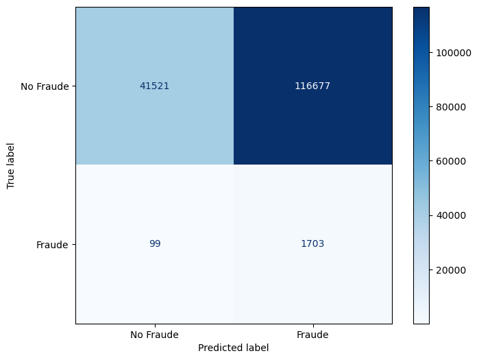

```
El script tardó 0 minutos y 1 segundos en ejecutarse.
```

```python
from sklearn.naive_bayes import GaussianNB
import time

start_time = time.time()

# Create a Gaussian Naive Bayes model
gnb = GaussianNB()

# Fit the model on the undersampled data
gnb.fit(X_resampled, y_resampled)

# Predict on the validation data
y_pred = gnb.predict(X_val)

# Evaluate the model
accuracy = accuracy_score(y_val, y_pred)
print("Accuracy of the Gaussian Naive Bayes model:", accuracy)

print("Classification Report:")
print(classification_report(y_val, y_pred))

print("Confusion Matrix:")
matriz = confusion_matrix(y_val, y_pred)
display_labels = ['No Fraude', 'Fraude']

vis = sklearn.metrics.ConfusionMatrixDisplay(matriz, display_labels=display_labels)
fig, ax = plt.subplots(figsize=(8, 6))
vis.plot(ax=ax, cmap='Blues', values_format='d', xticks_rotation='horizontal')
plt.show()

model_name = 'modelo_bayes_rus.pkl'
pickle_file_path = os.path.join(folder_path, model_name)
with open(pickle_file_path, 'wb') as file:
    pickle.dump(gnb, file)


end_time = time.time()

elapsed_time_seconds = end_time - start_time

elapsed_minutes = int(elapsed_time_seconds // 60)
elapsed_seconds = int(elapsed_time_seconds % 60)

print(f"El script tardó {elapsed_minutes} minutos y {elapsed_seconds} segundos en ejecutarse.")
```

# Modelo de Árbol

Un modelo de árbol es un tipo de modelo de aprendizaje automático que se utiliza tanto en problemas de clasificación como en problemas de regresión. La estructura del modelo se asemeja a un árbol con nodos internos y hojas. Cada nodo interno representa una prueba en una característica, cada rama representa el resultado de la prueba, y cada hoja representa la predicción o la clasificación final.

VALIDACIÓN

```python
model = DecisionTreeClassifier()
model.fit(X_resampled, y_resampled)
```

```
DecisionTreeClassifier()
```

```python
y_pred = model.predict(X_val)
```

```
Exactitud: 0.9324875
              precision    recall  f1-score   support

           0       0.99      0.94      0.96    158198
           1       0.05      0.30      0.09      1802

    accuracy                           0.93    160000
   macro avg       0.52      0.62      0.53    160000
weighted avg       0.98      0.93      0.96    160000

Matriz de Confusión:
```

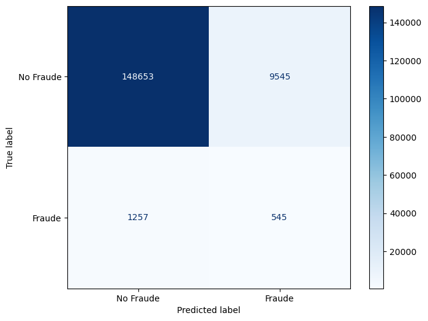

```
El script tardó 0.527623176574707 segundos en ejecutarse.
```

```python
from sklearn.metrics import accuracy_score, classification_report, confusion_matrix
import time
import pickle
start_time = time.time()

accuracy = accuracy_score(y_val, y_pred)
print("Exactitud:", accuracy)
print(classification_report(y_val, y_pred))
print("Matriz de Confusión:")
matriz=confusion_matrix(y_val, y_pred)
display_labels = ['No Fraude', 'Fraude']

vis = sklearn.metrics.ConfusionMatrixDisplay(matriz, display_labels=display_labels)
fig, ax = plt.subplots(figsize=(8, 6))
vis.plot(ax=ax, cmap='Blues', values_format='d', xticks_rotation='horizontal')
plt.show()

model_name = 'modelo_arbol_rus.pkl'
pickle_file_path = os.path.join(folder_path, model_name)
with open(pickle_file_path, 'wb') as file:
    pickle.dump(model, file)

end_time = time.time()
elapsed_time = end_time - start_time
print(f"El script tardó {elapsed_time} segundos en ejecutarse.")
```

# Support Vector Machine

El SVM es un conjunto de algoritmos de aprendizaje supervisado, que resuelve problemas de clasificación y regresión. Se parte de un problema binario, en nuestro caso si existe fraude (1) o no (0), de nuestra variable target 'fraud_bool'. Dicho problema binario debe ser linealmente separable. Cuantas más variables más difícil es.

Para entenderlo de manera más clara, un ejemplo podría ser el de crear una línea en una ubicación cualquiera e ir moviéndola hasta encontrar el menor posible. Hay que mencionar que es una línea en un plano de dos dimensiones (x,y), pero eso no significa que en el espacio sea una línea, ya que puede ser un plano o cualquier figura geométrica cuando lo observamos desde un plano de tres, cuatro, etc. dimensiones.

Los "support Vectors" son los puntos que se encuentran en las líneas discontinuas (azul y rosa). La línea negra sería la más óptima, donde el error es el menor entre ambas variables. Se sitúa a la misma distancia de las rectas azul y rosa, de manera que si salen nuevos puntos no salgan en la otra zona. Hay que dejar un margen amplio para no aumentar el error.

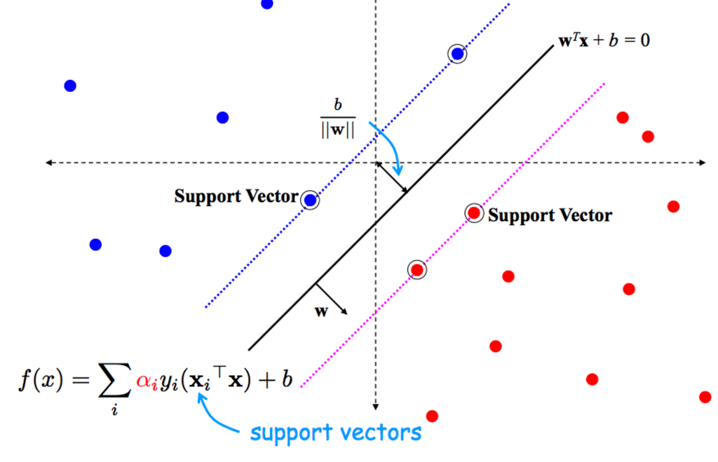

```
Precisión del modelo: 0.987175
Matriz de Confusión:
[[157750    448]
 [  1604    198]]
```

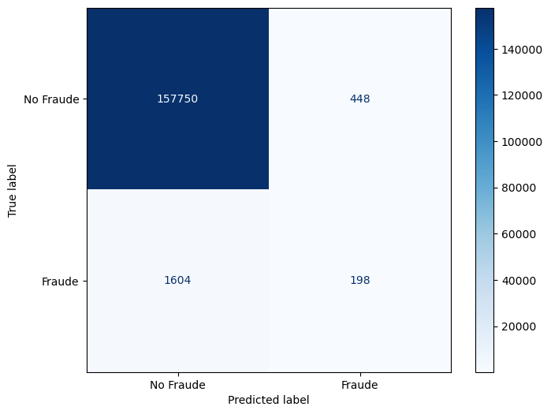

```
El script tardó 16 minutos y 1 segundos en ejecutarse.
```

```python
import time

start_time = time.time()
from sklearn.svm import SVC
svm_model = SVC()
svm_model.fit(X_resampled, y_resampled)

y_pred = svm_model.predict(X_val)

accuracy = accuracy_score(y_val, y_pred)
print(f'Precisión del modelo: {accuracy}')
print("Matriz de Confusión:")
matriz=confusion_matrix(y_val, y_pred)
print(matriz)

display_labels = ['No Fraude', 'Fraude']
# Crea la visualización de la matriz de confusión
vis = sklearn.metrics.ConfusionMatrixDisplay(matriz, display_labels=display_labels)
# Muestra el gráfico
fig, ax = plt.subplots(figsize=(8, 6))
vis.plot(ax=ax, cmap='Blues', values_format='d', xticks_rotation='horizontal')
plt.show()
model_name = 'svm_model_rus.pkl'
pickle_file_path = os.path.join(folder_path, model_name)
with open(pickle_file_path, 'wb') as file:
    pickle.dump(svm_model, file)

end_time = time.time()

elapsed_time_seconds = end_time - start_time

elapsed_minutes = int(elapsed_time_seconds // 60)
elapsed_seconds = int(elapsed_time_seconds % 60)

print(f"El script tardó {elapsed_minutes} minutos y {elapsed_seconds} segundos en ejecutarse.")
```

# RandomForest

El modelo RandomForest es un algoritmo de aprendizaje automático que construye múltiples árboles de decisión y combina sus predicciones para mejorar la robustez y generalización del modelo. La aleatoriedad en la selección de datos y características reduce el sobreajuste, y la predicción final se determina por votación (clasificación) o promediado (regresión) de los árboles. Es conocido por su rendimiento sólido y versatilidad en tareas de clasificación y regresión.

```
Exactitud: 0.98636
Reporte de Clasificación:
              precision    recall  f1-score   support

           0       0.99      1.00      0.99    197794
           1       0.26      0.13      0.17      2206

    accuracy                           0.99    200000
   macro avg       0.63      0.56      0.58    200000
weighted avg       0.98      0.99      0.98    200000

Matriz de Confusión:
[[196989    805]
 [  1923    283]]
```

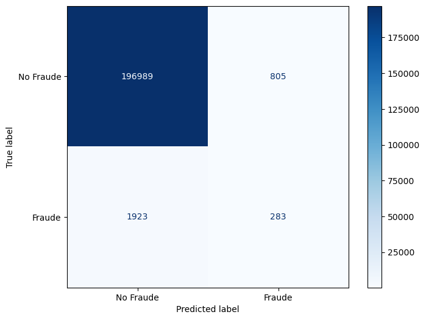

```
El script tardó 1 minutos y 3 segundos en ejecutarse.
```

```python
from sklearn.metrics import accuracy_score, classification_report, confusion_matrix
import time

start_time = time.time()

rf_model = RandomForestClassifier(random_state=42)
rf_model.fit(X_resampled, y_resampled)

y_pred = rf_model.predict(X_test_scaled)

accuracy = accuracy_score(y_test, y_pred)
print("Exactitud:", accuracy)

print("Reporte de Clasificación:")
print(classification_report(y_test, y_pred))
print("Matriz de Confusión:")
matriz2=confusion_matrix(y_test, y_pred)
print(matriz2)

display_labels = ['No Fraude', 'Fraude']

# Crea la visualización de la matriz de confusión
vis = sklearn.metrics.ConfusionMatrixDisplay(matriz2, display_labels=display_labels)

# Muestra el gráfico
fig, ax = plt.subplots(figsize=(8, 6))
vis.plot(ax=ax, cmap='Blues', values_format='d', xticks_rotation='horizontal')
plt.show()
model_name = 'randomforest_model_rus.pkl'
pickle_file_path = os.path.join(folder_path, model_name)
with open(pickle_file_path, 'wb') as file:
    pickle.dump(rf_model, file)

end_time = time.time()

elapsed_time_seconds = end_time - start_time

elapsed_minutes = int(elapsed_time_seconds // 60)
elapsed_seconds = int(elapsed_time_seconds % 60)

print(f"El script tardó {elapsed_minutes} minutos y {elapsed_seconds} segundos en ejecutarse.")
```

# Perception Learning Rule

El modelo Perception Learning Rule es un algoritmo de aprendizaje para un perceptrón, un tipo simple de red neuronal. Se utiliza para ajustar los pesos de entrada de manera que el perceptrón pueda clasificar correctamente las instancias de entrada. La regla de aprendizaje actualiza los pesos basándose en la diferencia entre la predicción del perceptrón y la clase real, multiplicada por las características de entrada.

```
Exactitud: 0.947625
Reporte de Clasificación:
              precision    recall  f1-score   support

           0       0.99      0.95      0.97    158198
           1       0.08      0.34      0.13      1802

    accuracy                           0.95    160000
   macro avg       0.53      0.65      0.55    160000
weighted avg       0.98      0.95      0.96    160000

Matriz de Confusión:
```

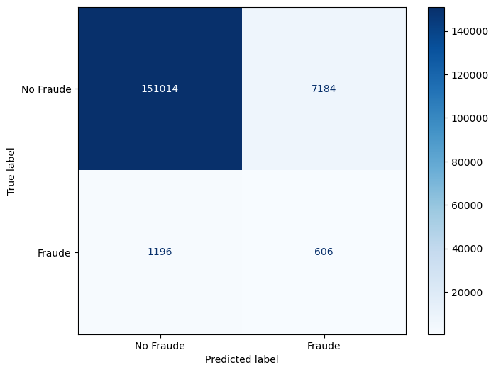

```
El script tardó 0 minutos y 0 segundos en ejecutarse.
```

```python
from sklearn.linear_model import Perceptron
import time

start_time = time.time()

# Crear un objeto Perceptrón
perceptron_model = Perceptron(random_state=42)

# Entrenar el modelo
perceptron_model.fit(X_resampled, y_resampled)

# Realizar predicciones en el conjunto de prueba
y_pred = perceptron_model.predict(X_val)

# Evaluar el rendimiento del modelo
accuracy = accuracy_score(y_val, y_pred)
print("Exactitud:", accuracy)

print("Reporte de Clasificación:")
print(classification_report(y_val, y_pred))

print("Matriz de Confusión:")
matriz3=confusion_matrix(y_val, y_pred)

# Supongamos que 'fraude' es la clase positiva (1) y 'no fraude' es la clase negativa (0)
display_labels = ['No Fraude', 'Fraude']

# Crea la visualización de la matriz de confusión
vis = sklearn.metrics.ConfusionMatrixDisplay(matriz3, display_labels=display_labels)

# Muestra el gráfico
fig, ax = plt.subplots(figsize=(8, 6))
vis.plot(ax=ax, cmap='Blues', values_format='d', xticks_rotation='horizontal')
plt.show()
model_name = 'perception_model_rus.pkl'
pickle_file_path = os.path.join(folder_path, model_name)
with open(pickle_file_path, 'wb') as file:
    pickle.dump(perceptron_model, file)

end_time = time.time()

elapsed_time_seconds = end_time - start_time

elapsed_minutes = int(elapsed_time_seconds // 60)
elapsed_seconds = int(elapsed_time_seconds % 60)

print(f"El script tardó {elapsed_minutes} minutos y {elapsed_seconds} segundos en ejecutarse.")
```

Aquí observamos un recall de unos bastante alto, pero los demás parámetros bajísimos en comparación con el resto de modelos.

# XGBOOST

El XGBoost es un algoritmo de aprendizaje automático que se destaca por su eficacia y velocidad. Se utiliza para problemas de clasificación y regresión. XGBoost significa "Extreme Gradient Boosting" y es una implementación optimizada de algoritmos de boosting. Combina múltiples modelos débiles (generalmente árboles de decisión) para mejorar la precisión general del modelo, minimizando el error de predicción.

```
Accuracy: 0.984075
Reporte de Clasificación:
              precision    recall  f1-score   support

           0       0.99      0.99      0.99    158198
           1       0.25      0.21      0.23      1802

    accuracy                           0.98    160000
   macro avg       0.62      0.60      0.61    160000
weighted avg       0.98      0.98      0.98    160000

Matriz de Confusión:
```

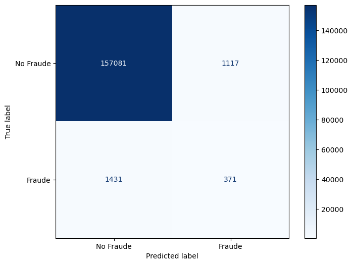

```
El script tardó 0 minutos y 1 segundos en ejecutarse.
```

```python
import xgboost as xgb
import time

start_time = time.time()

xgb_model = xgb.XGBClassifier(
    learning_rate=0.1,
    n_estimators=100,
    max_depth=3,
    min_child_weight=1,
    subsample=0.8,
    colsample_bytree=0.8,
    objective='binary:logistic',
    random_state=42
)

# Entrena el modelo
xgb_model.fit(X_resampled, y_resampled)

# Realiza predicciones en el conjunto de prueba
y_pred = xgb_model.predict(X_val)

# Evalúa la precisión del modelo
accuracy = accuracy_score(y_val, y_pred)
print("Accuracy:", accuracy)

print("Reporte de Clasificación:")
print(classification_report(y_val, y_pred))

print("Matriz de Confusión:")
matriz4=(confusion_matrix(y_val, y_pred))

# Supongamos que 'fraude' es la clase positiva (1) y 'no fraude' es la clase negativa (0)
display_labels = ['No Fraude', 'Fraude']

# Crea la visualización de la matriz de confusión
vis = sklearn.metrics.ConfusionMatrixDisplay(matriz4, display_labels=display_labels)

# Muestra el gráfico
fig, ax = plt.subplots(figsize=(8, 6))
vis.plot(ax=ax, cmap='Blues', values_format='d', xticks_rotation='horizontal')
plt.show()

model_name = 'xgb_model_rus.pkl'
pickle_file_path = os.path.join(folder_path, model_name)
with open(pickle_file_path, 'wb') as file:
    pickle.dump(xgb_model, file)

end_time = time.time()

elapsed_time_seconds = end_time - start_time

elapsed_minutes = int(elapsed_time_seconds // 60)
elapsed_seconds = int(elapsed_time_seconds % 60)

print(f"El script tardó {elapsed_minutes} minutos y {elapsed_seconds} segundos en ejecutarse.")
```

# GradientBoostClassifier

```python
from sklearn.ensemble import GradientBoostingClassifier
import time

start_time = time.time()

# Crear el clasificador GradientBoosting
gradientboost_model = GradientBoostingClassifier(n_estimators=100, learning_rate=0.1, max_depth=3, random_state=42)

# Entrenar el modelo
gradientboost_model.fit(X_resampled, y_resampled)

# Realizar predicciones en el conjunto de prueba
y_pred = gradientboost_model.predict(X_val)

# Evaluar el rendimiento del modelo
accuracy = accuracy_score(y_val, y_pred)
print("Exactitud:", accuracy)

print("Reporte de Clasificación:")
print(classification_report(y_val, y_pred))

print("Matriz de Confusión:")
matriz7=(confusion_matrix(y_val, y_pred))
# Supongamos que 'fraude' es la clase positiva (1) y 'no fraude' es la clase negativa (0)
display_labels = ['No Fraude', 'Fraude']

# Crea la visualización de la matriz de confusión
vis = sklearn.metrics.ConfusionMatrixDisplay(matriz7, display_labels=display_labels)

# Muestra el gráfico
fig, ax = plt.subplots(figsize=(8, 6))
vis.plot(ax=ax, cmap='Blues', values_format='d', xticks_rotation='horizontal')
plt.show()

model_name = 'gradientboost_model_rus.pkl'
pickle_file_path = os.path.join(folder_path, model_name)
with open(pickle_file_path, 'wb') as file:
    pickle.dump(gradientboost_model, file)

end_time = time.time()

elapsed_time_seconds = end_time - start_time

elapsed_minutes = int(elapsed_time_seconds // 60)
elapsed_seconds = int(elapsed_time_seconds % 60)

print(f"El script tardó {elapsed_minutes} minutos y {elapsed_seconds} segundos en ejecutarse.")
```

[output not shown]

# LightGBM

El LightGBM es una biblioteca eficiente de gradient boosting diseñada para entrenar modelos de aprendizaje automático de forma rápida y escalable, especialmente útil para conjuntos de datos grandes.

```python
import lightgbm as lgb
from sklearn.metrics import accuracy_score, classification_report, confusion_matrix

import time

start_time = time.time()

# Crear un objeto Dataset para LightGBM
train_data = lgb.Dataset(X_resampled, label=y_resampled)

# Configurar parámetros del modelo
params = {
    'objective': 'binary',
    'metric': 'binary_error',  # Puedes ajustar la métrica según tus necesidades
    'boosting_type': 'gbdt',
    'num_leaves': 31,
    'learning_rate': 0.05,
    'feature_fraction': 0.9
}

# Entrenar el modelo
num_round = 100  # Puedes ajustar el número de rondas según sea necesario
bst = lgb.train(params, train_data, num_round)

# Realizar predicciones en el conjunto de prueba
y_pred = bst.predict(X_val, num_iteration=bst.best_iteration)
y_pred_binary = [1 if prob >= 0.5 else 0 for prob in y_pred]

# Evaluar el rendimiento del modelo
accuracy = accuracy_score(y_val, y_pred_binary)
print("Exactitud:", accuracy)

print("Reporte de Clasificación:")
print(classification_report(y_val, y_pred_binary))

print("Matriz de Confusión:")
matriz8=(confusion_matrix(y_val, y_pred_binary))
# Supongamos que 'fraude' es la clase positiva (1) y 'no fraude' es la clase negativa (0)
display_labels = ['No Fraude', 'Fraude']

# Crea la visualización de la matriz de confusión
vis = sklearn.metrics.ConfusionMatrixDisplay(matriz8, display_labels=display_labels)

# Muestra el gráfico
fig, ax = plt.subplots(figsize=(8, 6))
vis.plot(ax=ax, cmap='Blues', values_format='d', xticks_rotation='horizontal')
plt.show()

model_name = 'LightGBM_model_rus.pkl'
pickle_file_path = os.path.join(folder_path, model_name)
with open(pickle_file_path, 'wb') as file:
    pickle.dump(bst, file)

end_time = time.time()

elapsed_time_seconds = end_time - start_time

elapsed_minutes = int(elapsed_time_seconds // 60)
elapsed_seconds = int(elapsed_time_seconds % 60)

print(f"El script tardó {elapsed_minutes} minutos y {elapsed_seconds} segundos en ejecutarse.")
```

[output not shown]

# AdaBoost Classifier

El modelo AdaBoost es un algoritmo que combina varios modelos débiles para formar un modelo fuerte. Se enfoca en las instancias mal clasificadas, asignándoles más peso en cada iteración. De esta manera, sucesivos modelos se centran en corregir los errores del modelo anterior, mejorando la precisión global.

```
Exactitud: 0.98076875
Reporte de Clasificación:
              precision    recall  f1-score   support

           0       0.99      0.99      0.99    158198
           1       0.21      0.26      0.23      1802

    accuracy                           0.98    160000
   macro avg       0.60      0.62      0.61    160000
weighted avg       0.98      0.98      0.98    160000

Matriz de Confusión:
```

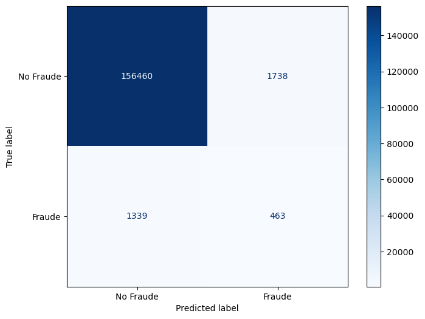

```
El script tardó 0 minutos y 19 segundos en ejecutarse.
```

```python
from sklearn.ensemble import AdaBoostClassifier
import time
import os
import pickle

start_time = time.time()

base_classifier = DecisionTreeClassifier(max_depth=1)

# Crear el clasificador AdaBoost
adaboost_model = AdaBoostClassifier(base_classifier, n_estimators=50, random_state=42)

# Entrenar el modelo
adaboost_model.fit(X_resampled, y_resampled)

# Realizar predicciones en el conjunto de prueba
y_pred = adaboost_model.predict(X_val)

# Evaluar el rendimiento del modelo
accuracy = accuracy_score(y_val, y_pred)
print("Exactitud:", accuracy)

print("Reporte de Clasificación:")
print(classification_report(y_val, y_pred))

print("Matriz de Confusión:")
matriz5=(confusion_matrix(y_val, y_pred))

import sklearn.metrics
import matplotlib.pyplot as plt

# Supongamos que 'fraude' es la clase positiva (1) y 'no fraude' es la clase negativa (0)
display_labels = ['No Fraude', 'Fraude']

# Crea la visualización de la matriz de confusión
vis = sklearn.metrics.ConfusionMatrixDisplay(matriz5, display_labels=display_labels)

# Muestra el gráfico
fig, ax = plt.subplots(figsize=(8, 6))
vis.plot(ax=ax, cmap='Blues', values_format='d', xticks_rotation='horizontal')
plt.show()
model_name = 'ada_model_rus.pkl'
pickle_file_path = os.path.join(folder_path, model_name)
with open(pickle_file_path, 'wb') as file:
    pickle.dump(adaboost_model, file)

end_time = time.time()

elapsed_time_seconds = end_time - start_time

elapsed_minutes = int(elapsed_time_seconds // 60)
elapsed_seconds = int(elapsed_time_seconds % 60)

print(f"El script tardó {elapsed_minutes} minutos y {elapsed_seconds} segundos en ejecutarse.")
```

### Segundo undersampling unido con el modelo escogido

```python
from imblearn.under_sampling import RandomUnderSampler

count_class_0, count_class_1 = y_train.value_counts()

# Establecer la proporción deseada
undersampling_ratio_0 = 0.85  # Eliminar el 85% de la clase 0
undersampling_ratio_1 = 0 # Eliminar el 0% de la clase 1

# Calcular el nuevo número de instancias después del undersampling
target_count_class_0 = int(count_class_0 * (1 - undersampling_ratio_0))
target_count_class_1 = int(count_class_1 * (1 - undersampling_ratio_1))

# Configurar el RandomUnderSampler con las proporciones deseadas
rus = RandomUnderSampler(sampling_strategy={0: target_count_class_0, 1: target_count_class_1}, random_state=42)

# Aplicar el undersampling al conjunto de entrenamiento
X_resampled_unido, y_resampled_unido = rus.fit_resample(X_train_scaled, y_train)
```

# **MODELO FINAL ESCOGIDO**

```
Fitting 5 folds for each of 10 candidates, totalling 50 fits
Accuracy en el conjunto de prueba: 0.982785
Reporte de Clasificación:
              precision    recall  f1-score   support

           0       0.99      0.99      0.99    197794
           1       0.23      0.25      0.24      2206

    accuracy                           0.98    200000
   macro avg       0.61      0.62      0.62    200000
weighted avg       0.98      0.98      0.98    200000

Matriz de Confusión:
```

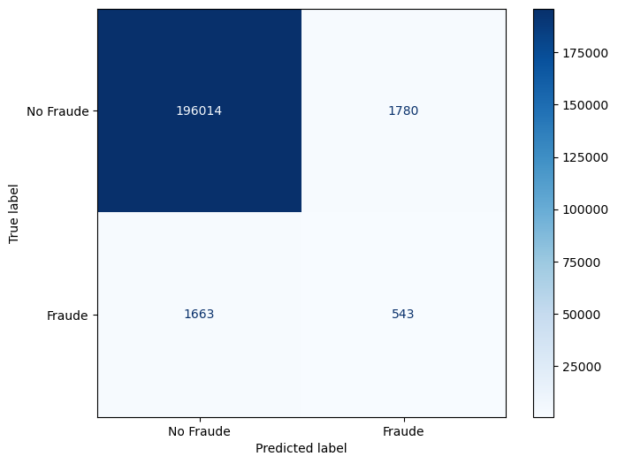

```
El script tardó 31 minutos y 32 segundos en ejecutarse.
```

```python
from sklearn.ensemble import AdaBoostClassifier
from sklearn.model_selection import RandomizedSearchCV
from sklearn.datasets import make_classification
from scipy.stats import randint
from sklearn.tree import DecisionTreeClassifier
import time

start_time = time.time()


# Supongamos que tienes tus datos X_train, X_test, y_train, y_test después del oversampling

# Define el modelo base (árbol de decisión) para AdaBoost
base_estimator = DecisionTreeClassifier(max_depth=1)

# Define el modelo AdaBoost con el estimador base
base_model = AdaBoostClassifier(base_estimator=base_estimator)

# Define el espacio de búsqueda de hiperparámetros
param_dist = {
    'n_estimators': randint(50, 200),  # Rango para el número de estimadores
    'learning_rate': [0.01, 0.05, 0.1, 0.5, 1],  # Valores posibles para la tasa de aprendizaje
    'algorithm': ['SAMME', 'SAMME.R'],  # Algoritmo de boosting
    'base_estimator__max_depth': [1, 2, 3],  # Profundidad máxima de los árboles base
    'base_estimator__min_samples_split': [2, 5, 10],  # Mínimo de muestras requeridas para dividir un nodo
    'base_estimator__min_samples_leaf': [1, 2, 4],  # Mínimo de muestras requeridas para ser una hoja
    'base_estimator__criterion': ['gini', 'entropy'],
}

# Inicializa el RandomizedSearchCV
random_search = RandomizedSearchCV(
    base_model,
    param_distributions=param_dist,
    n_iter=10,  # Número de combinaciones aleatorias a probar
    scoring='accuracy',  # Puedes cambiar esto por otras métricas si lo deseas
    cv=5,  # Número de pliegues en la validación cruzada
    verbose=1,
    n_jobs=-1  # Usa todos los núcleos disponibles
)

# Realiza la búsqueda de hiperparámetros
random_search.fit(X_resampled_unido, y_resampled_unido)


# Evalúa el modelo con los mejores hiperparámetros en el conjunto de prueba
best_model = random_search.best_estimator_
accuracy = best_model.score(X_test_scaled, y_test)
print("Accuracy en el conjunto de prueba:", accuracy)
y_pred = random_search.predict(X_test_scaled)

print("Reporte de Clasificación:")
print(classification_report(y_test, y_pred))

print("Matriz de Confusión:")
matriz6=(confusion_matrix(y_test, y_pred))
# Supongamos que 'fraude' es la clase positiva (1) y 'no fraude' es la clase negativa (0)
display_labels = ['No Fraude', 'Fraude']

# Crea la visualización de la matriz de confusión
vis = sklearn.metrics.ConfusionMatrixDisplay(matriz6, display_labels=display_labels)

# Muestra el gráfico
fig, ax = plt.subplots(figsize=(8, 6))
vis.plot(ax=ax, cmap='Blues', values_format='d', xticks_rotation='horizontal')
plt.show()

with open('modelo_final.pkl', 'wb') as file:
    pickle.dump(best_model, file)
end_time = time.time()
model_name = 'mejor_modelo_rus.pkl'
pickle_file_path = os.path.join(folder_path, model_name)
with open(pickle_file_path, 'wb') as file:
    pickle.dump(best_model, file)

elapsed_time_seconds = end_time - start_time

elapsed_minutes = int(elapsed_time_seconds // 60)
elapsed_seconds = int(elapsed_time_seconds % 60)

print(f"El script tardó {elapsed_minutes} minutos y {elapsed_seconds} segundos en ejecutarse.")
```

Con este modelo final obtenemos una accuracy de 0.98, una precisión de 0.23, un recall de 0.25 y un f1-score de 0.24. El modelo detecta un total de 543 fraudes que luego son fraudes, al final lo que estamos buscando es encontrar el mayor número de fraudes sin que se eleven mucho los otros valores de la matriz de confusión.

# **EXPLICABILIDAD**

Una vez elegido el modelo final, se observará la explicabilidad de dicho modelo. La explicabilidad es la capacidad de comprender y explicar las decisiones o predicciones de un modelo de manera clara y comprensible. Para observarla utilizaremos la técnica SHAP, presente en la introducción de este notebook.

### Representación de los valores SHAP para las características en el conjunto de prueba

```python
explainer = shap.KernelExplainer(best_model.predict_proba, X_resampled_unido.iloc[:100, :])
```

```python
shap_values = explainer.shap_values(X_test_scaled.iloc[:100, :])
```

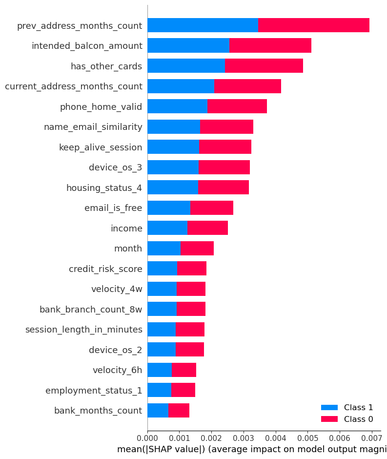

```python
shap.summary_plot(shap_values, X_test_scaled.iloc[:100, :], max_display=20)
```

Además,la longitud total de la barra representa la magnitud total de la contribución de la característica para una muestra específica. Cuanto más larga sea la barra, mayor es la contribución de esa característica para la predicción del modelo en esa muestra.Por lo tanto, la variable que más contribuye al modelo de AdaBoost sería prev_adress_months_count, es decir, Número de meses en la dirección anterior registrada del solicitante, es decir, la residencia anterior del solicitante, si corresponde,que varía entre 0 y 380 meses y sin embargo la que menos contribución ha generado al modelo es la de bank_months_count, que representa el tiempo que tiene la cuenta creada en meses.

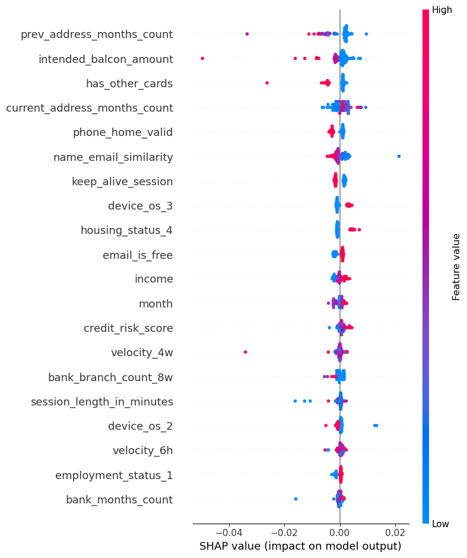

```python
# Asumiendo que X_test_scaled es un DataFrame con nombres de columnas
shap.summary_plot(shap_values[1], features=X_test_scaled.values[:100, :], feature_names=X_test_scaled.columns, max_display=20)
```

# Curva ROC

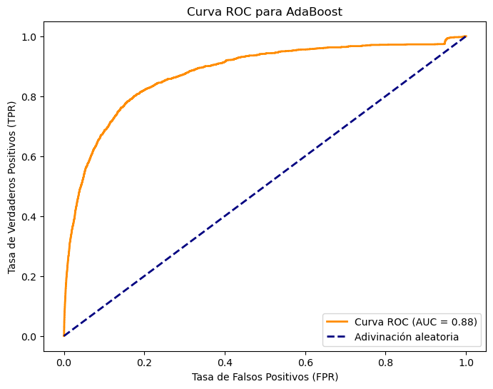

```python
from sklearn.metrics import roc_curve, auc
y_prob = best_model.predict_proba(X_test_scaled)[:, 1]

# Calcula la curva ROC
fpr, tpr, thresholds = roc_curve(y_test, y_prob)
roc_auc = auc(fpr, tpr)

# Visualiza la curva ROC
plt.figure(figsize=(8, 6))
plt.plot(fpr, tpr, color='darkorange', lw=2, label=f'Curva ROC (AUC = {roc_auc:.2f})')
plt.plot([0, 1], [0, 1], color='navy', lw=2, linestyle='--', label='Adivinación aleatoria')
plt.xlabel('Tasa de Falsos Positivos (FPR)')
plt.ylabel('Tasa de Verdaderos Positivos (TPR)')
plt.title('Curva ROC para AdaBoost')
plt.legend(loc='lower right')
plt.show()
```

La Curva ROC (Receiver Operating Characteristic) es una representación gráfica del rendimiento de un modelo de clasificación a varios umbrales de discriminación. Esta curva representa la tasa de verdaderos positivos (TPR) en el eje y, y la tasa de falsos positivos (FPR) en el eje x. La TPR se refiere a la proporción de instancias positivas que el modelo clasifica correctamente, mientras que la FPR se refiere a la proporción de instancias negativas que el modelo clasifica incorrectamente como positivas.Por ejemplo, cuando FPR es 0.2 y TPR es 0.8, significa que el modelo tiene una tasa de falsos positivos del 20% y una tasa de verdaderos positivos del 80% en ese umbral particular de discriminación.

El AUC(Area Under the Curve) mide la capacidad del modelo para distinguir entre clases positivas y negativas.En este caso, nuestro AUC es de 0.88, esto indica que el modelo tiene un buen rendimiento en la clasificación. Un AUC de 1.0 significaría que el modelo clasifica perfectamente todas las instancias, mientras que un AUC de 0.5 indica un rendimiento similar al azar.

# Importancia de las variables

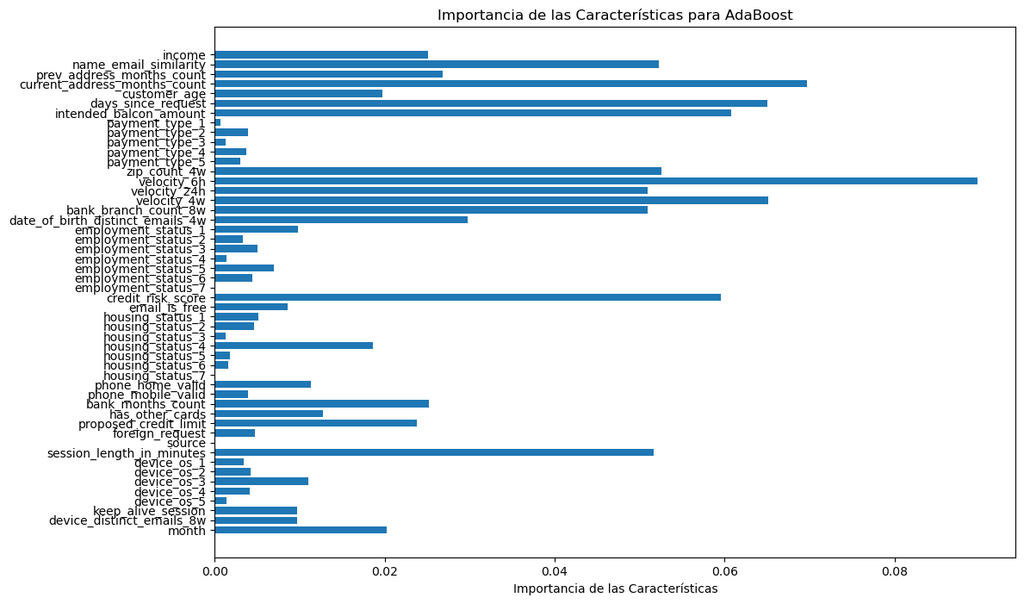

```python
from sklearn.datasets import make_classification
feature_names = X_resampled_unido.columns

# Ajusta la separación entre las barras y el tamaño del gráfico
fig, ax = plt.subplots(figsize=(12, 8))
bar_positions = np.arange(len(feature_names))
bar_width = 0.75  # Ajusta según sea necesario

# Crea un gráfico de barras de importancia de características
ax.barh(bar_positions, feature_importance, height=bar_width, align='center')
ax.set_yticks(bar_positions)
ax.set_yticklabels(feature_names)
ax.invert_yaxis()  # Invierte el eje y para tener la característica más importante arriba
ax.set_xlabel('Importancia de las Características')
ax.set_title('Importancia de las Características para AdaBoost')

plt.show()
```

En el gráfico de importancia de características creado a partir del mejor modelo(AdaBoost), cada barra representa la importancia relativa de una característica en la toma de decisiones del modelo. La importancia de las características se calcula basándose en cómo cada característica contribuye a la reducción del error durante el proceso de entrenamiento.Es decir, la barra más larga velocity_6h siendo esta el número promedio de solicitudes por hora en las últimas 6 horas, es la que más importancia tiene para la clasificación y tiene un impacto significativo en la mejora de la precisión del modelo.Sin embargo otra como payment_type_1 que representa un tipo de pago crediticio tiene una importancia muy baja, prácticamente nula.

### OVERFITTING

Para terminar observaremos si nuestro modelo tiene overfitting. El overfitting ocurre cuando un modelo se ajusta demasiado a los datos de train y captura patrones que no son generalizables a datos nuevos. Esto conlleva un mal uso de los datos no vistos.

```python
import pickle
ruta_del_pickle = '../models/mejor_modelo_rus.pkl'

# Cargar el modelo desde el archivo pickle
with open(ruta_del_pickle, 'rb') as file:
    loaded_model = pickle.load(file)
```

```python
y_train_pred=loaded_model.predict(X_resampled_unido)
y_test_pred=loaded_model.predict(X_test_scaled)
```

```python
precision_entrenamiento = accuracy_score(y_resampled_unido, y_train_pred)
precision_prueba = accuracy_score(y_test, y_test_pred)

print("Precisión en Conjunto de Entrenamiento:", precision_entrenamiento)
print("Precisión en Conjunto de Prueba:", precision_prueba)
```

```
Precisión en Conjunto de Entrenamiento: 0.9309014188346575
Precisión en Conjunto de Prueba: 0.988915
```

## CONCLUSIONES FINALES

En este trabajo principal de la asignatura hemos aprendido como trabajar con datos, como tratar un dataset desde cero, con todos los problemas que eso conlleva. Hemos entendido el proceso de inicio a fin de la selección de modelos más óptimos para su aplicación en la vida real. Este trabajo nos ha parecido bastante interesante, ya que hemos podido encontrar un modelo que predice cuando los usuarios van a ser fraudes incluso antes de que hagan ningún movimiento.

Este trabajo ha permitido resolver el desafío de detectar fraudes en una entidad bancaria. Comenzamos con el Análisis Exploratorio de Datos (EDA), que nos proporcionó una comprensión profunda de la distribución y la naturaleza de las variables en nuestro conjunto de datos. Este paso fue crucial para identificar posibles patrones, anomalías y relaciones que podrían afectar nuestra tarea de detección de fraudes.

La selección de variables fue otro aspecto fundamental, donde evaluamos y elegimos las características más relevantes y significativas para mejorar la eficacia del modelo. A través del Feature Engineering, fuimos capaces de crear nuevas variables y transformar las existentes, optimizando así la capacidad predictiva de nuestro modelo.

En la fase de selección de modelos probamos diferentes algoritmos, desde modelos más simples hasta enfoques más complejos, evaluando su rendimiento mediante métricas como precisión, recall y F1-score. A través de este proceso, identificamos el modelo que mejor se ajusta a nuestras necesidades de detección de fraudes.

Para terminar, nuestro modelo se desempeñó de manera satisfactoria al predecir la existencia de fraudes en la entidad bancaria. La combinación de un EDA exhaustivo, selección cuidadosa de variables, ingeniería de características efectiva y elección adecuada de modelos ha resultado en un sistema robusto y confiable para completa este desafío en el sector financiero. Este enfoque no solo mejora la precisión de las predicciones, sino que también aporta a dar valor al sector de riesgos y fortalece la seguridad en el ámbito bancario.

El modelo final elegido ha sido el ADABoost Classifier, e incluso habíamos obtenido mejores valores pero a la hora de hacer el pickle esos valores cambiaban. Adjuntamos foto de nuestros mejores resultados obtenidos, también del ADABoost con los mismos hiperparámetros que el actual:

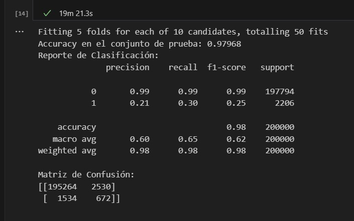